# Pythonic Syntactic Sugar

The Image Basics Notebook was straight forward and closely follows ITK's C++ interface.

Sugar is great it gives your energy to get things done faster! SimpleITK has applied a generous about of syntactic sugar to help get things done faster too.

```python
%matplotlib inline
import matplotlib.pyplot as plt
import matplotlib as mpl

mpl.rc("image", aspect="equal")
import SimpleITK as sitk

# Download data to work on
%run update_path_to_download_script
from downloaddata import fetch_data as fdata
```

Let us begin by developing a convenient method for displaying images in our notebooks.

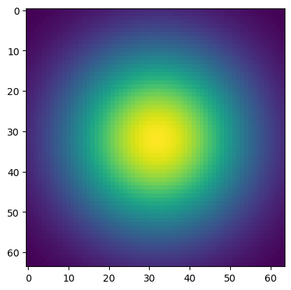

```python
img = sitk.GaussianSource(size=[64] * 2)
plt.imshow(sitk.GetArrayViewFromImage(img))
```

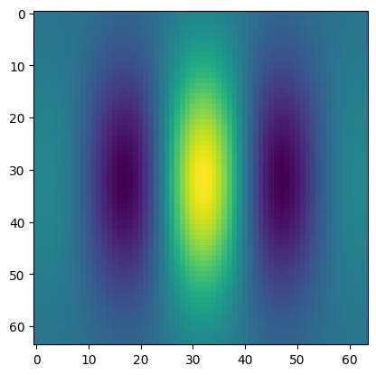

```python
img = sitk.GaborSource(size=[64] * 2, frequency=0.03)
plt.imshow(sitk.GetArrayViewFromImage(img))
```

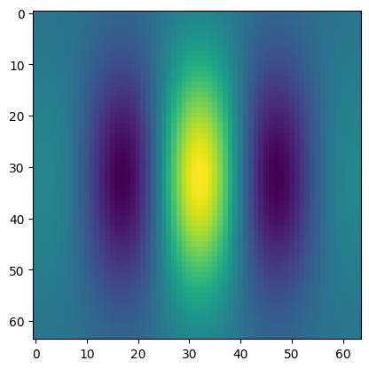

```python
def myshow(img):
    nda = sitk.GetArrayViewFromImage(img)
    plt.imshow(nda)


myshow(img)
```

## Multi-dimension slice indexing

If you are familiar with numpy, sliced index then this should be cake for the SimpleITK image. The Python standard slice interface for 1-D object:

| Operation | Result |
| --- | --- |
| d[i] | i-th item of d, starting index 0 |
| d[i:j] | slice of d from i to j |
| d[i:j:k] | slice of d from i to j with step k |

With this convenient syntax many basic tasks can be easily done.

```python
img[24, 24]
```

```
0.048901304602622986
```

### Cropping

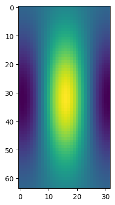

```python
myshow(img[16:48, :])
```

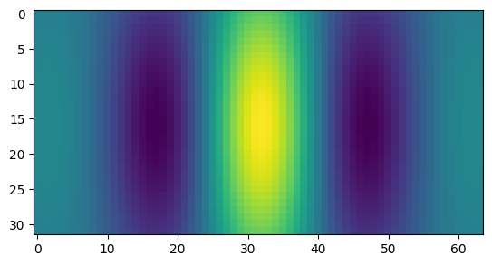

```python
myshow(img[:, 16:-16])
```

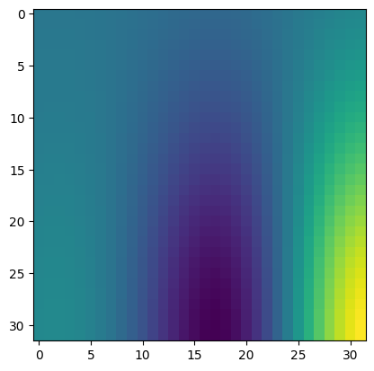

```python
myshow(img[:32, :32])
```

### Flipping

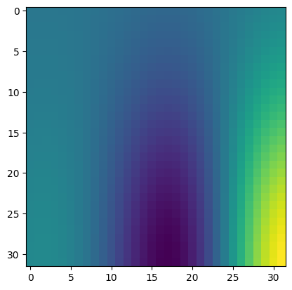

```python
img_corner = img[:32, :32]
myshow(img_corner)
```

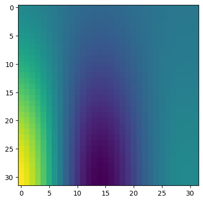

```python
myshow(img_corner[::-1, :])
```

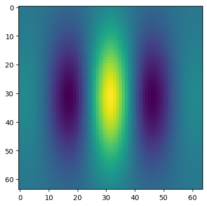

```python
myshow(
    sitk.Tile(
        img_corner,
        img_corner[::-1, ::],
        img_corner[::, ::-1],
        img_corner[::-1, ::-1],
        [2, 2],
    )
)
```

### Slice Extraction

A 2D image can be extracted from a 3D one.

[output not shown]

[output cut: 25 more lines]

[output not shown]

[figure not shown]

```python
img = sitk.GaborSource(size=[64] * 3, frequency=0.05)

# Why does this produce an error?
myshow(img)
```

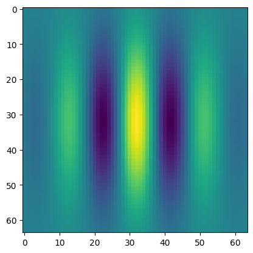

```python
myshow(img[:, :, 32])
```

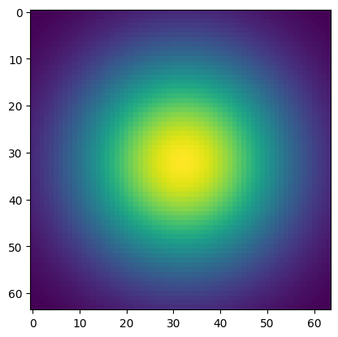

```python
myshow(img[16, :, :])
```

### Subsampling

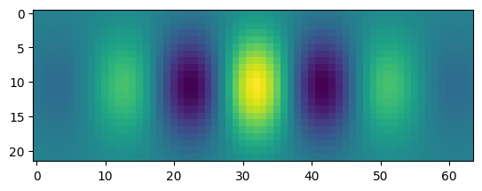

```python
myshow(img[:, ::3, 32])
```

## Mathematical Operators

Most python mathematical operators are overloaded to call the SimpleITK filter which does that same operation on a per-pixel basis. They can operate on a two images or an image and a scalar.

If two images are used then both must have the same pixel type. The output image type is usually the same.

As these operators basically call ITK filter, which just use raw C++ operators, care must be taken to prevent overflow, and divide by zero etc.

| Operators |
| --- |
| + |
| - |
| * |
| / |
| // |
| ** |

```python
img = sitk.ReadImage(fdata("cthead1.png"))
img = sitk.Cast(img, sitk.sitkFloat32)
myshow(img)
img[150, 150]
```

[output not shown]

```
Fetching cthead1.png
```

```
libpng warning: sCAL: invalid unit
libpng warning: sCAL: invalid unit
libpng warning: sCAL: invalid unit
```

```
140.0
```

[output not shown]

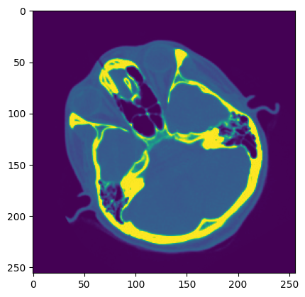

```python
timg = img**2
myshow(timg)
timg[150, 150]
```

### Division Operators

All three Python division operators are implemented `__floordiv__`, `__truediv__`, and `__div__`.

The true division's output is a double pixel type.

See [PEP 238](http://www.python.org/peps/pep-0238) to see why Python changed the division operator in Python 3.

### Bitwise Logic Operators

| Operators |
| --- |
| & |
| \| |
| ^ |
| ~ |

```python
img = sitk.ReadImage(fdata("cthead1.png"))
myshow(img)
```

[output not shown]

```
Fetching cthead1.png
```

```
libpng warning: sCAL: invalid unit
libpng warning: sCAL: invalid unit
libpng warning: sCAL: invalid unit
```

## Comparative Operators

| Operators |
| --- |
| > |
| >= |
| < |
| <= |
| == |

These comparative operators follow the same convention as the reset of SimpleITK for binary images. They have the pixel type of `sitkUInt8` with values of 0 and 1.

```python
img = sitk.ReadImage(fdata("cthead1.png"))
myshow(img)
```

[output not shown]

```
Fetching cthead1.png
```

```
libpng warning: sCAL: invalid unit
libpng warning: sCAL: invalid unit
libpng warning: sCAL: invalid unit
```

### Amazingly make common trivial tasks really trivial

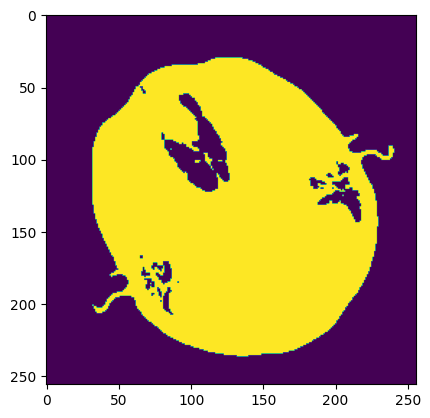

```python
myshow(img > 90)
```

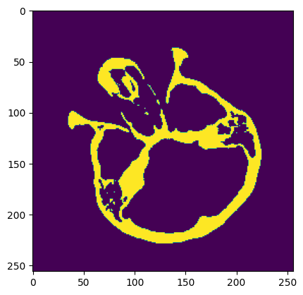

```python
myshow(img > 150)
```

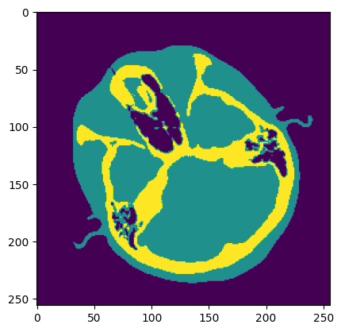

```python
myshow((img > 90) + (img > 150))
```

### Masking

Set the values in an image according to a given mask.

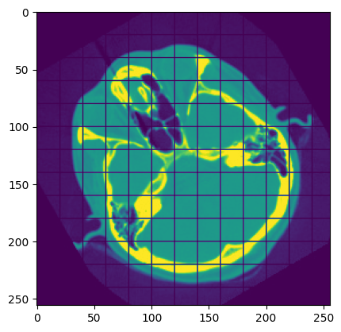

```python
# Create a grid and use as mask
grid_image = sitk.GridSource(
    outputPixelType=sitk.sitkUInt16,
    size=img.GetSize(),
    sigma=(0.1, 0.1),
    gridSpacing=(20.0, 20.0),
)
# zero out the values in the original image that correspond to
# the grid lines in the grid_image
img[grid_image == 0] = 0
myshow(img)
```